# Dim-reduction

Star Li

3/12/2020

```r
# load the data into the environment
data(mnist)
mnist_y = mnist[['Ytrain']]
mnist_X = data.frame(mnist[['Xtrain']])
mnist_X[['Group']] = as.factor(mnist_y)
```

## PCA

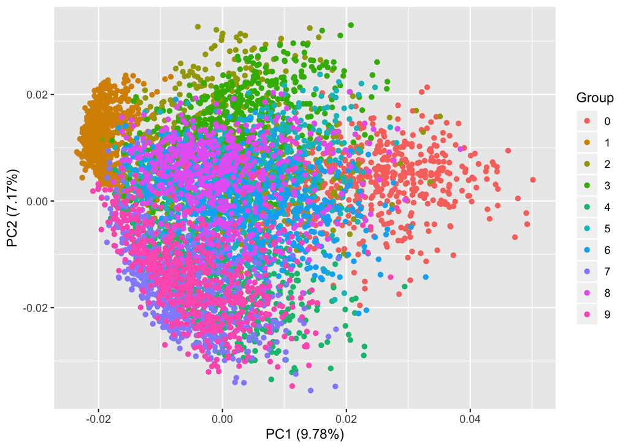

```r
mnist.pca = prcomp(mnist_X[,1:784])
pca.plot = autoplot(mnist.pca, data = mnist_X, colour = "Group")
pca.plot
```

## TSNE-analysis

```r
tsne.plot <- function(perpl=30, iterations=500, learning=200){
  set.seed(12345) # for reproducibility
  tsne <- Rtsne(mnist_X[,-785], dims = 2, perplexity=perpl, verbose=TRUE, max_iter=iterations, eta=learning)
  return(tsne)
}

mnist.tsne = tsne.plot()
```

```
## Performing PCA
## Read the 6000 x 50 data matrix successfully!
## OpenMP is working. 1 threads.
## Using no_dims = 2, perplexity = 30.000000, and theta = 0.500000
## Computing input similarities...
## Building tree...
## Done in 3.15 seconds (sparsity = 0.020409)!
## Learning embedding...
## Iteration 50: error is 91.498117 (50 iterations in 0.83 seconds)
## Iteration 100: error is 84.739909 (50 iterations in 0.85 seconds)
## Iteration 150: error is 82.937491 (50 iterations in 0.73 seconds)
## Iteration 200: error is 82.864019 (50 iterations in 0.72 seconds)
## Iteration 250: error is 82.831435 (50 iterations in 0.72 seconds)
## Iteration 300: error is 2.664572 (50 iterations in 0.66 seconds)
## Iteration 350: error is 2.287861 (50 iterations in 0.62 seconds)
## Iteration 400: error is 2.098730 (50 iterations in 0.64 seconds)
## Iteration 450: error is 1.981542 (50 iterations in 0.65 seconds)
## Iteration 500: error is 1.901911 (50 iterations in 0.65 seconds)
## Fitting performed in 7.06 seconds.
```

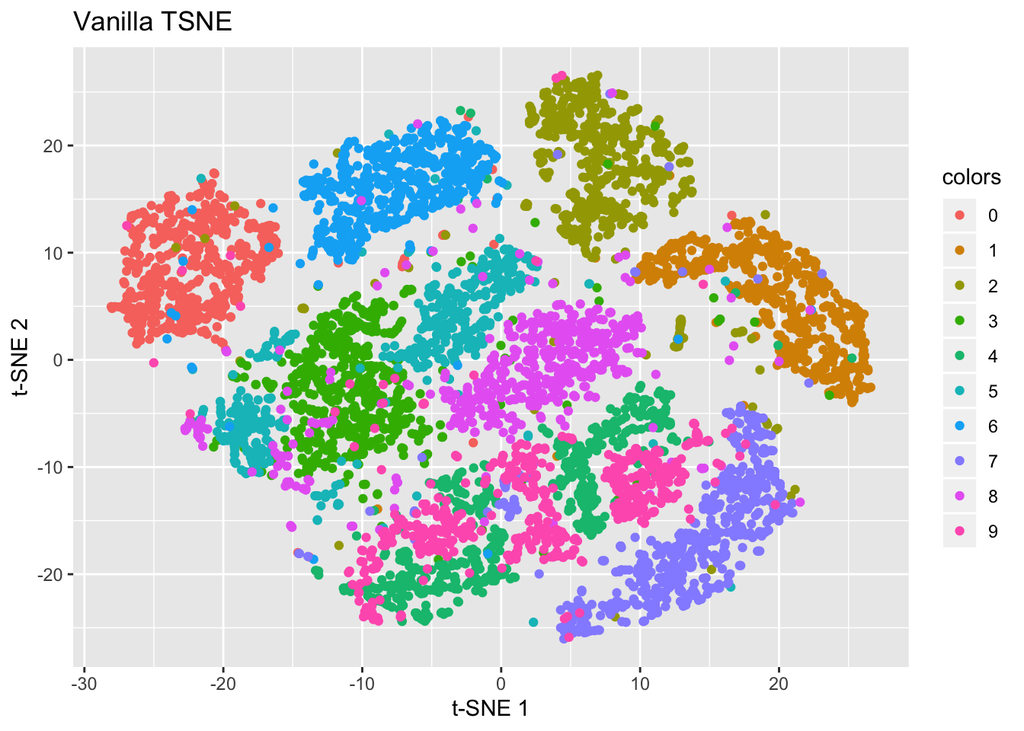

```r
ggplot() + geom_point(aes(x = mnist.tsne$Y[, 1], y = (x = mnist.tsne$Y[, 2]), color = mnist_X$Group)) + labs(title = "Vanilla TSNE", x = "t-SNE 1", y = "t-SNE 2", color = "colors")
```

By changing the hyper-parameters (perplexity, learning rate, iterations etc) we can get different results.

```r
mnist.tsne = tsne.plot(perpl = 2)
```

```
## Performing PCA
## Read the 6000 x 50 data matrix successfully!
## OpenMP is working. 1 threads.
## Using no_dims = 2, perplexity = 2.000000, and theta = 0.500000
## Computing input similarities...
## Building tree...
## Done in 2.33 seconds (sparsity = 0.001430)!
## Learning embedding...
## Iteration 50: error is 122.236729 (50 iterations in 0.89 seconds)
## Iteration 100: error is 107.099357 (50 iterations in 0.81 seconds)
## Iteration 150: error is 99.777196 (50 iterations in 0.63 seconds)
## Iteration 200: error is 96.180624 (50 iterations in 0.61 seconds)
## Iteration 250: error is 93.908246 (50 iterations in 0.62 seconds)
## Iteration 300: error is 4.342705 (50 iterations in 0.63 seconds)
## Iteration 350: error is 3.623279 (50 iterations in 0.67 seconds)
## Iteration 400: error is 3.148134 (50 iterations in 0.71 seconds)
## Iteration 450: error is 2.810212 (50 iterations in 0.71 seconds)
## Iteration 500: error is 2.558619 (50 iterations in 0.72 seconds)
## Fitting performed in 7.00 seconds.
```

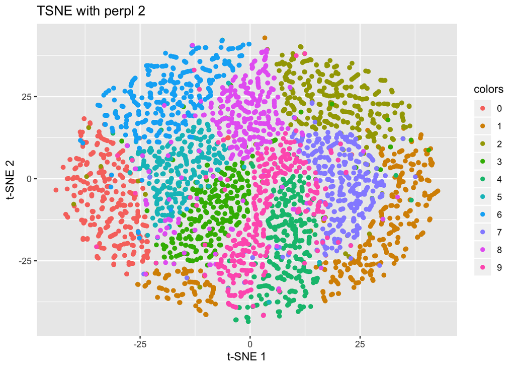

```r
ggplot() + geom_point(aes(x = mnist.tsne$Y[, 1], y = (x = mnist.tsne$Y[, 2]), color = mnist_X$Group)) + labs(title = "TSNE with perpl 2", x = "t-SNE 1", y = "t-SNE 2", color = "colors")
```

So by the above tuning of the parameter perplexity, we see that higher perplexity seems to pull different clusters further away from each other. This does make sense since perplexity is tightly related to the optimal sigma we use for the normal distribution in high dimensional space.

## UMAP Analysis

#### For the UMAP visualization, we will use the `umap` package.

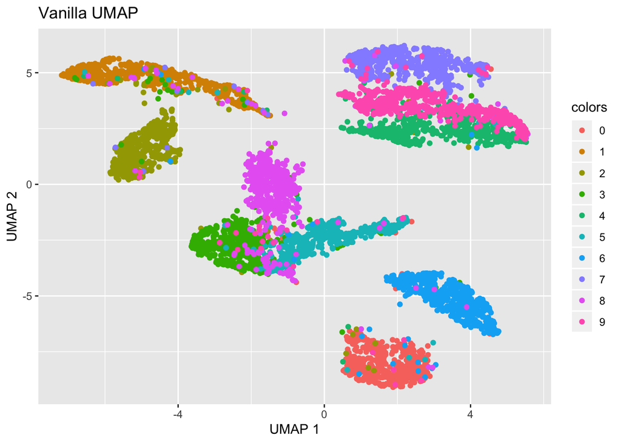

```r
# The vanilla UMAP dimensionality reduction (default parameters)
mnist.umap = umap(mnist_X[,-785])

ggplot() + geom_point(aes(x = mnist.umap$layout[, 1], y = (x = mnist.umap$layout[, 2]), color = mnist_X$Group)) + labs(title = "Vanilla UMAP", x = "UMAP 1", y = "UMAP 2", color = "colors")
```

The most important hyperparameters for UMAP are the k neighbors and min_dist. We will tune them individually to see how the layout changes.

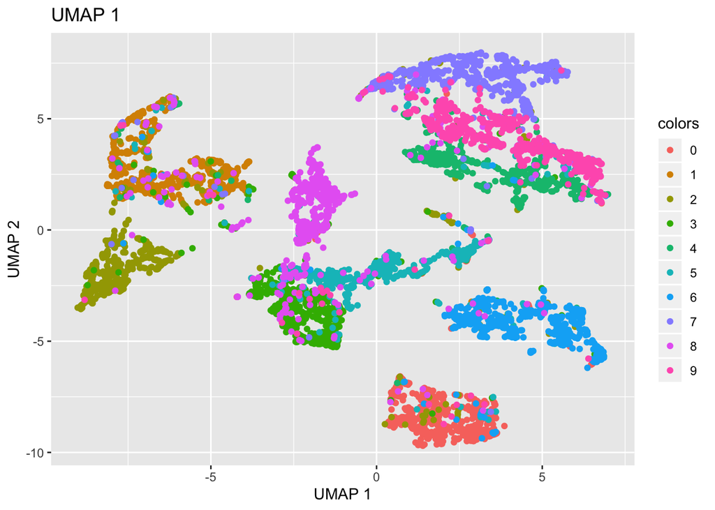

```r
config1 = umap.defaults
# default for neighbors is 15. Since there are only 10 classes, 5 seems ok.
config1$n_neighbors = 5

mnist.umap1 = umap(mnist_X[,-785], config1)

ggplot() + geom_point(aes(x = mnist.umap1$layout[, 1], y = (x = mnist.umap1$layout[, 2]), color = mnist_X$Group)) + labs(title = "UMAP 1", x = "UMAP 1", y = "UMAP 2", color = "colors")
```

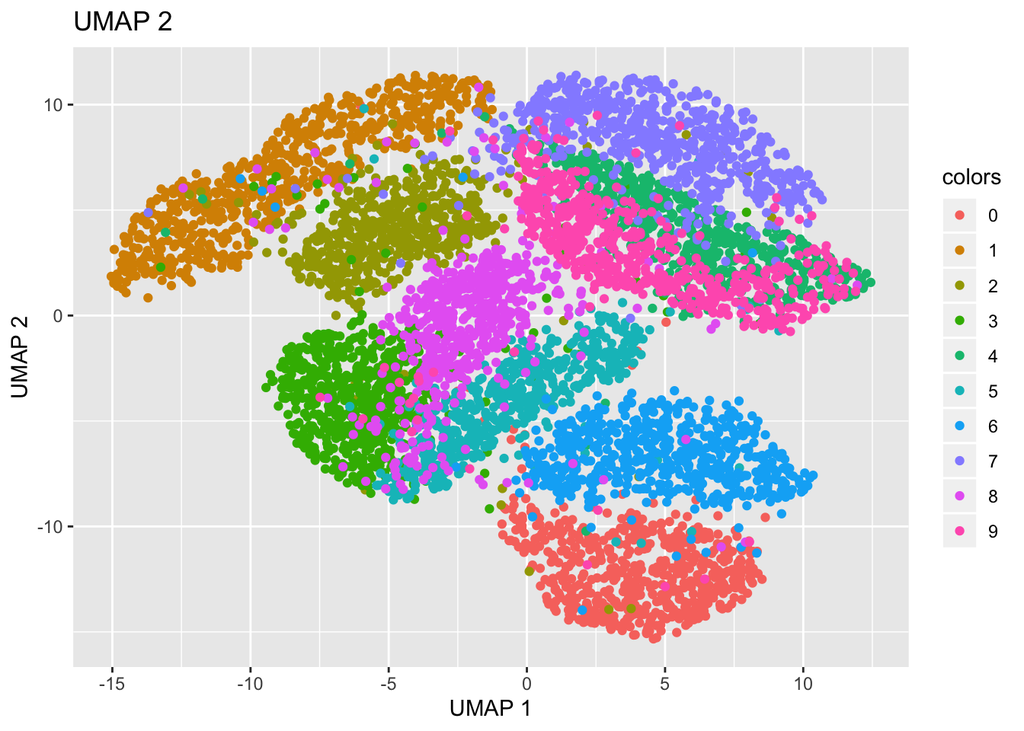

```r
config2 = umap.defaults
# default for neighbors is 15. Since there are only 10 classes, 5 seems ok.
config2$spread = 1.5
config2$min_dist = 1

mnist.umap2 = umap(mnist_X[,-785], config2)

ggplot() + geom_point(aes(x = mnist.umap2$layout[, 1], y = (x = mnist.umap2$layout[, 2]), color = mnist_X$Group)) + labs(title = "UMAP 2", x = "UMAP 1", y = "UMAP 2", color = "colors")
```

#### Brief comparison between UMAP and TSNE on maintaining global structure

When tuning different hyper-parameters for t-SNE, we observe that the relative position for some clusters have been changed in the process even though the clusters themselves are preserved (which shows how t-SNE focuses on similar points). For UMAP, the general layout between different groups are better preserved despite hyper-parameter changes. So the distances between clusters in UMAP’s case can be more reliable. As a trade-off, we can see that t-SNE offers a clearer boundary for each cluster.

#### About the speed of UMAP, TSNE

I don’t see how UMAP is much faster than TSNE as many people online claim. One reason can be that I’m using random (not really) packages found online to perform these operations and the optimizations behind are inside the blackboxes (e.g. the t-SNE algorithm uses a really quick PCA technique for preprocessing). Also, my computer is a laptop so some advantage of UMAP in gradient descent might not get fully expressed.